# Heat Shock, Cancer Style

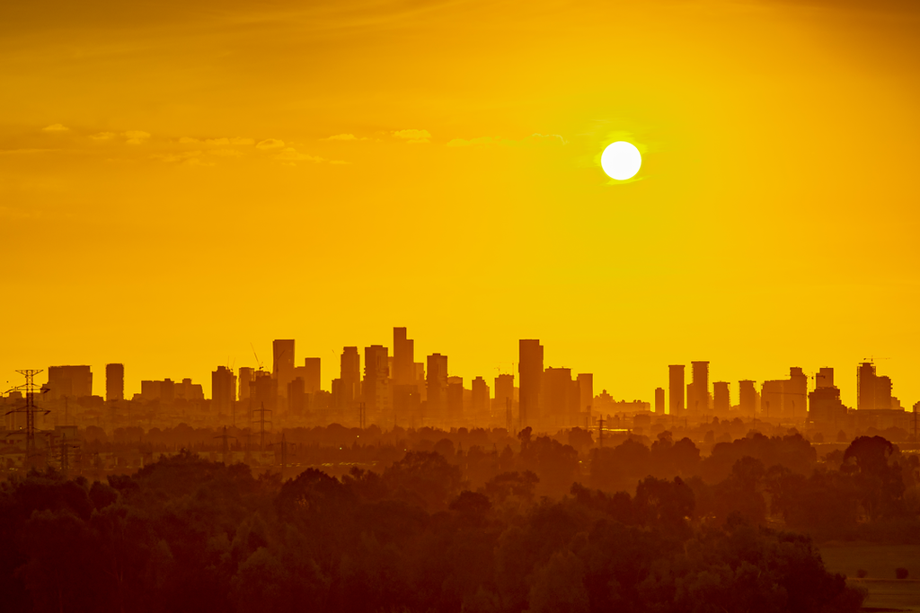

In a study from CSU Fullerton, scientists used **transcriptomic data** to explore how human cells respond to heat shock at the molecular level. Their findings revealed both expected and unexpected stress responses, offering new insight into how cells cope under pressure (Reinschmidt et al., 2023).

# What is Heat Shock Response?

**ImportantRecall the time you were sick?**

You might have a had fever. This caused your body to undergo alot of stress, but instead of shutting down, it activates protective systems to help you recover and keep going.

All cells experience some form of stress, whether from heat, toxins, or infections. Heat stress, in particular, can cause proteins inside cells to misfold. When this happens, cells activate the **Heat Shock Response (HSR),** their built-in survival system.

# What are Heat Shock Proteins?

Once the HSR is triggered, cells begin producing special proteins called **heat shock proteins (HSPs)**. Their job includes:

- Help proteins fold correctly
- Repair damaged ones
- Prevent future protein misfolding

**TipHow is this Relevant?**

In the CSU Fullerton study, researchers observed the *expected* activation of classic heat shock proteins like **HSP70 and HSP90**. But they also found activation of **non-canonical responses** which are genes not traditionally associated with heat shock (Reinschmidt et al., 2023).

This suggests the HSR is **more complex and far-reaching than we previously thought**, with variations depending on the cell type.

# Cancer Cells Survival Strategy

**ImportantThe Problem with Cancer Cells**

Cancer cells are under constant stress. Low oxygen, exposure to radiation, and chemotherapy are just a few. But instead of dying under this pressure (as treatments intend), cancer cells ramp up their production of HSPs. **Cancer cells hijack the heat shock response** **to avoid death.**

By overactivating the HSR, cancer cells become **practically immune**, withstanding chemotherapy, radiation, and other treatments that would normally kill them. This ability to exploit the heat shock response is part of what makes cancer so difficult to treat.

# Our Offense to Cancers Defense

The discovery of **non-canonical HSR pathways** opens new possibilities for cancer treatment. If we can figure out how to **selectively block the amplified heat shock response in cancer cells**, we could make them more vulnerable to therapy.

In other words, disabling cancer’s stress-coping tricks could **improve the effects of chemotherapy** and other treatment outcomes. Understanding how cancer cells produce HSPs differently than normal cells is key to reaching the full potential of cancer therapy.

**TipTakeaway**

This research shows how **basic cell biology** is important to **real-world medicine.** By uncovering new information on heat shock response, scientists have identified new targets to research that could be used to outsmart cancer and possibly other diseases that exploit stress responses

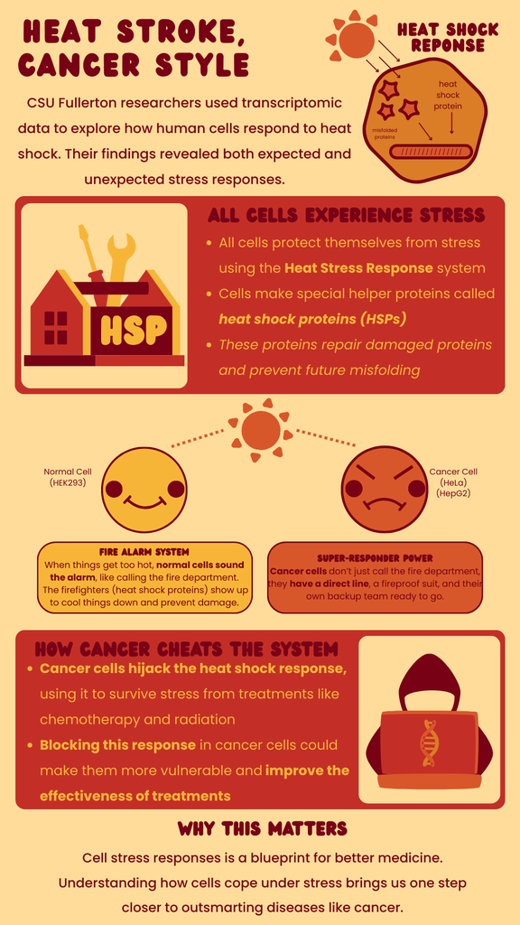

Infographic Recap

## References

Reinschmidt, A., Solano, L., Chavez, Y., Hulsy, W. D., & Nikolaidis, N. (2023). Transcriptomics unveil canonical and non-canonical heat shock-induced pathways in human cell lines. *International Journal of Molecular Sciences*, *26*(3), 1057. https://doi.org/10.3390/ijms26031057